### Course 8 project

## Analysis of the quality of exercise taken, using data from a number of different exercise recording devices

# Executive Summary

This report explores not what kind of activity is taken but how well it is taken. To do this I’ve used data on 6 participants who were asked to do a series of exercises correctly and incorrectly.

# Data Cleaning and Exploration

First we download the training and test datasets

```r
library(caret)
```

```r
library(rpart)
library(rpart.plot)
library(rattle)
url_train <- "https://d396qusza40orc.cloudfront.net/predmachlearn/pml-training.csv"
url_test <- "https://d396qusza40orc.cloudfront.net/predmachlearn/pml-testing.csv"
download.file(url_train, destfile = "train_data.csv")
download.file(url_test, destfile = "test_data.csv")

train_data <- read.csv("~/DataScience/Course8_PracticalMachineLearning/train_data.csv")
test_data <- read.csv("~/DataScience/Course8_PracticalMachineLearning/test_data.csv")
```

```r
train_clean <- train_data[,-c(1:7)]
remove_blanks <- which(colSums(is.na(train_clean) |train_clean=="")>0.9*dim(train_clean)[1])
train_clean <- train_clean[,-remove_blanks]

test_clean <- test_data[,-c(1,7)]
remove_blanks2 <- which(colSums(is.na(test_clean) |test_clean=="")>0.9*dim(test_clean)[1])
test_clean <- test_clean[,-remove_blanks2]
```

First we will split the training data into a training dataset and a validation set where we will test our final model before applying to the test set and submitting.

```r
set.seed(383)
inTrain <- createDataPartition(train_clean$classe, p=0.7, list= FALSE)
training <- train_clean[inTrain,]
validation <- train_clean[-inTrain,]

dim(training)
```

```
## [1] 13737    53
```

```r
dim(validation)
```

```
## [1] 5885   53
```

```r
levels(training$classe)
```

```
## [1] "A" "B" "C" "D" "E"
```

# Model Building

In order to avoid overfitting and to assess the effectiveness of our models we will use cross-validation in all of our models. We will fit a number of models and assess their accuracy giving us a sense of their out of sample error rate.

# Model 1: Classification Tree

```r
set.seed(111)
mod_cv <- trainControl(method="cv", number=3, verboseIter=FALSE)
modfit_ct<- train(classe~., data=training, method="rpart", trControl=mod_cv)
modfit_ct$finalModel
```

```
## n= 13737
##
## node), split, n, loss, yval, (yprob)
##       * denotes terminal node
##
##  1) root 13737 9831 A (0.28 0.19 0.17 0.16 0.18)
##    2) roll_belt< 130.5 12591 8695 A (0.31 0.21 0.19 0.18 0.11)
##      4) pitch_forearm< -33.95 1091    8 A (0.99 0.0073 0 0 0) *
##      5) pitch_forearm>=-33.95 11500 8687 A (0.24 0.23 0.21 0.2 0.12)
##       10) magnet_dumbbell_y< 439.5 9723 6970 A (0.28 0.18 0.24 0.19 0.11)
##         20) roll_forearm< 123.5 6069 3597 A (0.41 0.18 0.18 0.17 0.062) *
##         21) roll_forearm>=123.5 3654 2450 C (0.077 0.18 0.33 0.23 0.19) *
##       11) magnet_dumbbell_y>=439.5 1777  860 B (0.034 0.52 0.043 0.22 0.19) *
##    3) roll_belt>=130.5 1146   10 E (0.0087 0 0 0 0.99) *
```

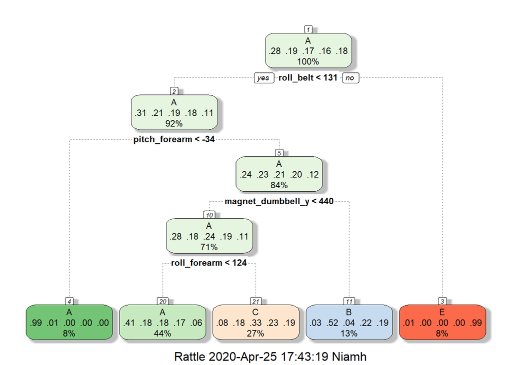

```r
rattle::fancyRpartPlot(modfit_ct$finalModel)
```